# Project 2 — Data Tidying

Author

Shawn Ganz

Published

March 8, 2026

## Approach

I’ll use the following data:

- [Dataset_1](https://brightspace.cuny.edu/d2l/le/1154241/discussions/threads/4168991/View)
  - df_1
- [Dataset_2](https://brightspace.cuny.edu/d2l/le/1154241/discussions/threads/4206056/View)
  - df_2
- [Dataset_3](https://brightspace.cuny.edu/d2l/le/1154241/discussions/threads/4224007/View)
  - df_3
  - Wasn’t wide, so I have to make it wide

```r
df <- data.frame(
  Quarter = c("Q1","Q2","Q3","Q4"),
  Lakers = c(28,32,25,30),
  Celtics = c(31,29,33,28),
  Warriors = c(25,27,35,30)
)

write.csv(df, "data_03.csv", row.names = FALSE)
```

put csv’s onto github read csv in project

- `url -> "github_raw_link"`
- `library(tidyverse)`
- `df <- read_csv("url")`

**Analysis for df_1**

Fix the brackets, there are too many.

**Analysis for df_2**

The only real wide portion of the dataset is the months. So, make that into months using `pivot_longer()` and try and fix the craziness of screeningscores and `pivot_wider()` PHQ and GAD. Limit selection to a couple of rows and then see if there’s anything to analyze.

Could show off age, month, and values.

- Summary table
  - group age, month
  - summarize
    - values
- ggplot
  - x = age
  - y = values
  - cols
- Description
  - findings

**Analysis for df_3**

Simple one, will just `pivot_longer()` team names into new column, values to score.

- Summary table
  - entire dataset
- ggplot
  - x = quarter
  - y = scores
  - fill = team
  - cols
- Description
  - review the chart

## Codebase

**Reading**

```r
library(tidyverse)
url_1 <- "https://raw.githubusercontent.com/Siganz/CUNY_Assignments/refs/heads/main/607/project_02/data_01.csv"
url_2 <- "https://raw.githubusercontent.com/Siganz/CUNY_Assignments/refs/heads/main/607/project_02/data_02.csv"
url_3 <- "https://raw.githubusercontent.com/Siganz/CUNY_Assignments/refs/heads/main/607/project_02/data_03.csv"

df_1 <- read_csv(url_1)
df_2 <- read_csv(url_2)
df_3 <- read_csv(url_3)

#df_all <- c(df_1, df_2, df_3)
#glimpse(df_all <- c(df_1, df_2, df_3))

glimpse(df_1)
```

```
Rows: 14
Columns: 11
$ Religion             <chr> "Agnostic", "Atheist", "Buddhist", "Catholic", "E…
$ `<$10k`              <dbl> 27, 12, 27, 418, 575, 9, 228, 20, 19, 289, 34, 23…
$ `$10-20k`            <dbl> 34, 27, 21, 617, 869, 7, 244, 27, 19, 495, 42, 23…
$ `$20-30k`            <dbl> 60, 37, 30, 732, 1064, 9, 236, 24, 25, 619, 37, 1…
$ `$30-40k`            <dbl> 81, 52, 34, 670, 982, 11, 238, 24, 25, 655, 48, 1…
$ `$40-50k`            <dbl> 76, 39, 33, 638, 881, 13, 197, 21, 30, 651, 51, 1…
$ `$50-75k`            <dbl> 137, 81, 58, 1116, 1486, 34, 212, 30, 73, 1107, 1…
$ `$75-100k`           <dbl> 102, 76, 62, 949, 949, 47, 156, 15, 59, 939, 87, …
$ `$100-150k`          <dbl> 109, 59, 39, 792, 723, 48, 156, 11, 87, 792, 96, …
$ `>$150k`             <dbl> 84, 74, 53, 792, 414, 54, 78, 6, 151, 753, 64, 41…
$ `Don't know/refused` <dbl> 96, 76, 54, 1163, 1529, 37, 339, 37, 87, 1096, 10…
```

```r
glimpse(df_2)
```

```
Rows: 180
Columns: 21
$ RecordID        <dbl> 1, 2, 3, 4, 5, 6, 7, 8, 9, 10, 11, 12, 13, 14, 15, 16,…
$ Participant     <chr> "Participant_1", "Participant_2", "Participant_3", "Pa…
$ AgeGroup        <chr> "unknown", "unknown", "26-35", "36-45", "36-45", "18-2…
$ Gender          <chr> "F", "n/a", "M", "Female", "Female", "Female", "Other"…
$ City_State      <chr> "Phoenix, AZ", "Houston, TX", "Chicago, IL", "Houston,…
$ ScreeningScores <chr> "PHQ9:9,GAD7:0", "PHQ-9=2;GAD-7=9", "PHQ-9=20;GAD-7=13…
$ Jan             <chr> NA, NA, "-", "n/a", NA, "missing", "n/a", "140", "miss…
$ Feb             <chr> "-", "missing", "missing", "n/a", NA, NA, NA, "119", "…
$ Mar             <chr> "-", "n/a", "n/a", NA, "n/a", NA, NA, "111", "n/a", NA…
$ Apr             <chr> "n/a", "n/a", "-", NA, "n/a", NA, "n/a", "-", NA, NA, …
$ May             <chr> "-", "n/a", NA, "missing", "missing", NA, NA, "missing…
$ TherapyType     <chr> "Group", "ACT", "n/a", "CBT", "Group", "CBT", "CBT", "…
$ Sessions        <chr> "18", NA, "n/a", "n/a", "9", "8", "n/a", NA, "n/a", NA…
$ Medication      <chr> NA, "SNRI", "None", "None", NA, "None", "SSRI", "SSRI"…
$ DiagnosisStatus <chr> "Undiagnosed", "-", "Pending", "Undiagnosed", "-", NA,…
$ WorkHours       <chr> NA, NA, NA, "n/a", "36h", "n/a", "33 hours", "57h", NA…
$ Sleep           <chr> "missing", NA, "missing", "missing", NA, NA, "8.7 hour…
$ StressScale     <chr> NA, NA, NA, NA, "10", NA, NA, "7", "2", "3", "n/a", "n…
$ Insurance       <chr> "Private", "-", "Public", NA, "Public", "Public", "-",…
$ SurveyDate      <chr> "2024-03-12", "2025-05-21", "03-30-2024", "2025-06-14"…
$ Notes           <chr> "missing", "missing", NA, "Follow-up needed", "Increas…
```

```r
glimpse(df_3)
```

```
Rows: 4
Columns: 4
$ Quarter  <chr> "Q1", "Q2", "Q3", "Q4"
$ Lakers   <dbl> 28, 32, 25, 30
$ Celtics  <dbl> 31, 29, 33, 28
$ Warriors <dbl> 25, 27, 35, 30
```

**Cleaning**

```r
religion_df <- df_1 |>
  rename(religion = Religion) |>
  mutate(
  low = rowSums(across(c(`<$10k`, `$10-20k`, `$20-30k`, `$30-40k`, `$40-50k`))),
  mid = rowSums(across(c(, `$50-75k`, `$75-100k`))),
  high = rowSums(across(c(`$100-150k`, `>$150k`)))) |>
  select(religion, low, mid, high) |>
  pivot_longer(cols = -religion, names_to = "income_range", values_to = "n")
glimpse(religion_df)
```

```
Rows: 42
Columns: 3
$ religion     <chr> "Agnostic", "Agnostic", "Agnostic", "Atheist", "Atheist",…
$ income_range <chr> "low", "mid", "high", "low", "mid", "high", "low", "mid",…
$ n            <dbl> 278, 239, 193, 167, 157, 133, 145, 120, 92, 3075, 2065, 1…
```

```r
medical_df <- df_2 |>
  select(RecordID, AgeGroup, ScreeningScores, TherapyType, Jan, Feb, Mar, Apr, May) |>
  rename(id = RecordID, scores = ScreeningScores, age = AgeGroup) |>
  pivot_longer(cols = c(Jan, Feb, Mar, Apr, May), names_to = "month", values_to = "values") |>
  mutate(scores = str_replace(scores, ",\\s*", ";"),
         scores = str_replace_all(scores, "[:\\-=]", ""),
         scores = str_replace(scores, "GAD7", ""),
         scores = str_replace(scores, "PHQ9", ""))|>
  separate(col = scores, into = c("PHQ", "GAD7"), sep = ";") |>
  mutate(values = replace(values, values %in% c("-", "missing", "", "n/a"), NA)) |>
  mutate(value = as.integer(values), PHQ = as.integer(PHQ), GAD7 = as.integer(GAD7)) |>
  select(-values) |>
  mutate(TherapyType = ifelse(TherapyType == "n/a", "None", TherapyType),
         month = factor(month, levels = c("Jan", "Feb","Mar", "Apr", "May")))
glimpse(medical_df)
```

```
Rows: 900
Columns: 7
$ id          <dbl> 1, 1, 1, 1, 1, 2, 2, 2, 2, 2, 3, 3, 3, 3, 3, 4, 4, 4, 4, 4…
$ age         <chr> "unknown", "unknown", "unknown", "unknown", "unknown", "un…
$ PHQ         <int> 9, 9, 9, 9, 9, 2, 2, 2, 2, 2, 20, 20, 20, 20, 20, 24, 24, …
$ GAD7        <int> 0, 0, 0, 0, 0, 9, 9, 9, 9, 9, 13, 13, 13, 13, 13, 13, 13, …
$ TherapyType <chr> "Group", "Group", "Group", "Group", "Group", "ACT", "ACT",…
$ month       <fct> Jan, Feb, Mar, Apr, May, Jan, Feb, Mar, Apr, May, Jan, Feb…
$ value       <int> NA, NA, NA, NA, NA, NA, NA, NA, NA, NA, NA, NA, NA, NA, NA…
```

```r
basketball_df <- df_3 |> rename(quarter = Quarter) |>
  pivot_longer(cols = -quarter, names_to = "teams", values_to = "scores") |>
  mutate(quarter = factor(quarter, levels = c("Q1","Q2","Q3","Q4"))) |>
  arrange(teams)
glimpse(basketball_df)
```

```
Rows: 12
Columns: 3
$ quarter <fct> Q1, Q2, Q3, Q4, Q1, Q2, Q3, Q4, Q1, Q2, Q3, Q4
$ teams   <chr> "Celtics", "Celtics", "Celtics", "Celtics", "Lakers", "Lakers"…
$ scores  <dbl> 31, 29, 33, 28, 28, 32, 25, 30, 25, 27, 35, 30
```

**Religion Summarize + ggplot**

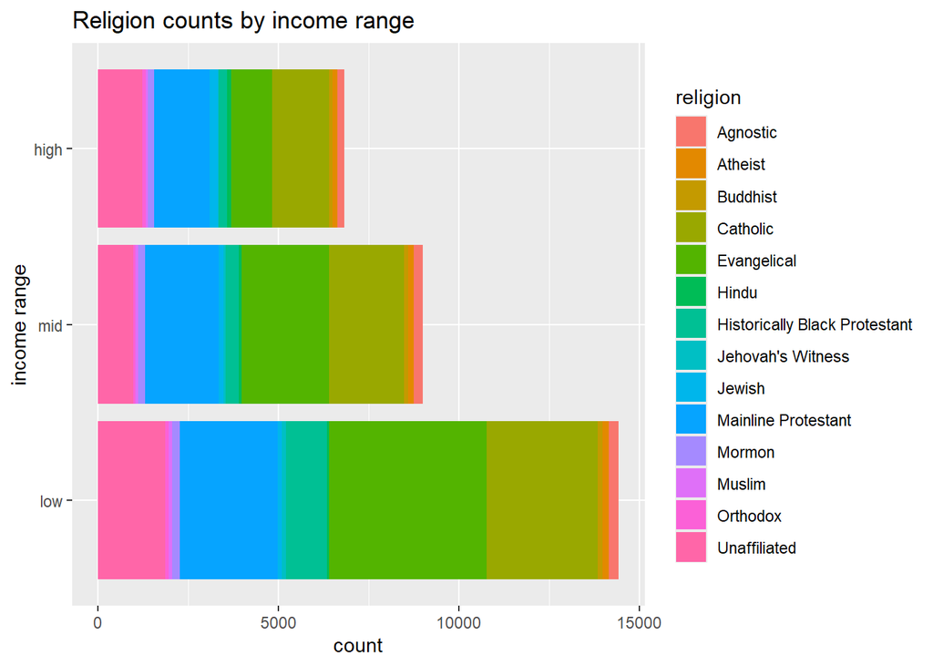

```r
library(ggthemes)

sum_religion <- religion_df |>
  mutate(income_range = factor(income_range, levels = c("low", "mid", "high"))) |>
  group_by(religion, income_range) |>
  summarize(n = sum(n))

sum_religion |>
  ggplot(aes(x = income_range, y = n, fill = religion)) +
  geom_col() +
  coord_flip() +
  labs(
    title = "Religion counts by income range",
    x = "income range",
    y = "count")
```

```r
religion_df |> group_by(religion) |>
  summarize(n = sum(n)) |>
  arrange(desc(n)) |>
  slice_head(n = 3)
```

```
# A tibble: 3 × 2
  religion                n
  <chr>               <dbl>
1 Evangelical          7943
2 Catholic             6724
3 Mainline Protestant  6300
```

```r
religion_df |> group_by(religion) |>
  summarize(n = sum(n)) |>
  arrange(n) |>
  slice_head(n = 3)
```

```
# A tibble: 3 × 2
  religion              n
  <chr>             <dbl>
1 Jehovah's Witness   178
2 Hindu               232
3 Muslim              234
```

According to the religion data, there are more patrons that are of the low income range ($0 - $50k), than the other income ranges. One notable pattern is that Orthodox has more patrons that are high income than mid income that can be visually determined.

The religions with the highest count of patrons: - Evangelical (7943) - Catholic (6724) - Mainline Protestant (6300)

The religions with the lowest count of patrons: - Jehovah’s Witness (178) - Hindu (232) - Muslim (234)

**Medical Summarize + ggplot**

```r
sum_medical <- medical_df |>
  rename(therapy = TherapyType) |>
  filter(!is.na(value)) |>
  group_by(therapy, month) |>
  summarize(n = sum(value),
            mean_phq = mean(PHQ, na.rm = TRUE),
            mean_gad = mean(GAD7, na.rm = TRUE),
            .groups = "drop")

glimpse(sum_medical)
```

```
Rows: 25
Columns: 5
$ therapy  <chr> "ACT", "ACT", "ACT", "ACT", "ACT", "CBT", "CBT", "CBT", "CBT"…
$ month    <fct> Jan, Feb, Mar, Apr, May, Jan, Feb, Mar, Apr, May, Jan, Feb, M…
$ n        <int> 650, 527, 756, 633, 268, 545, 728, 415, 646, 576, 427, 430, 6…
$ mean_phq <dbl> 12.166667, 9.600000, 12.428571, 17.400000, 17.500000, 11.0000…
$ mean_gad <dbl> 15.500000, 10.400000, 11.428571, 12.600000, 3.500000, 8.40000…
```

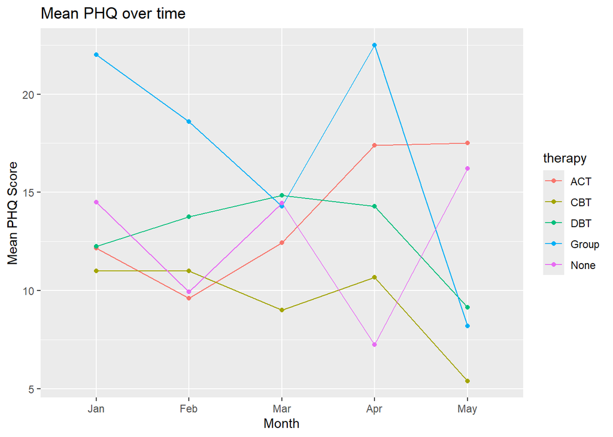

```r
sum_medical |>
  group_by(month, therapy) |>
  ggplot(aes(month, mean_phq, color = therapy, group = therapy)) +
  geom_line() +
  geom_point() +
  labs(title = "Mean PHQ over time",
       x = "Month",
       y = "Mean PHQ Score")
```

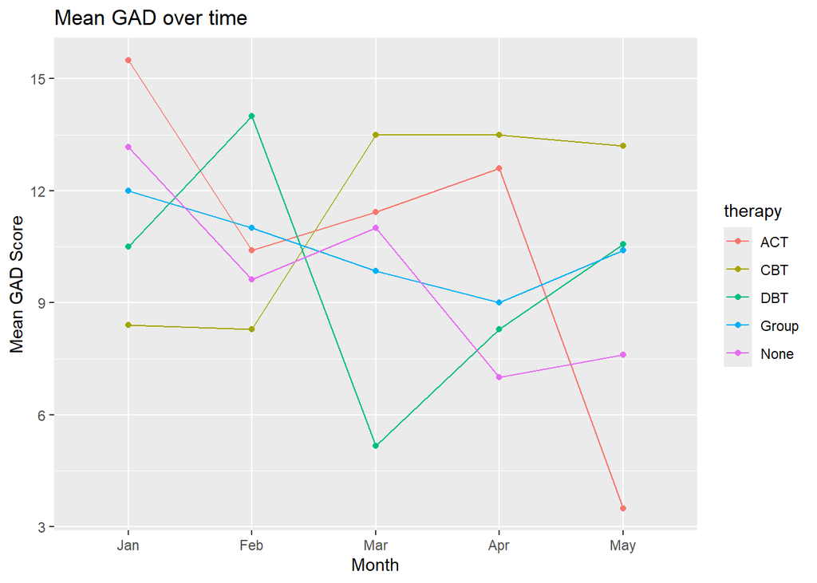

```r
sum_medical |>
  group_by(month, therapy) |>
  ggplot(aes(month, mean_gad, color = therapy, group = therapy)) +
  geom_line() +
  geom_point() +
  labs(title = "Mean GAD over time",
       x = "Month",
       y = "Mean GAD Score")
```

**Basketball Summarize + ggplot**

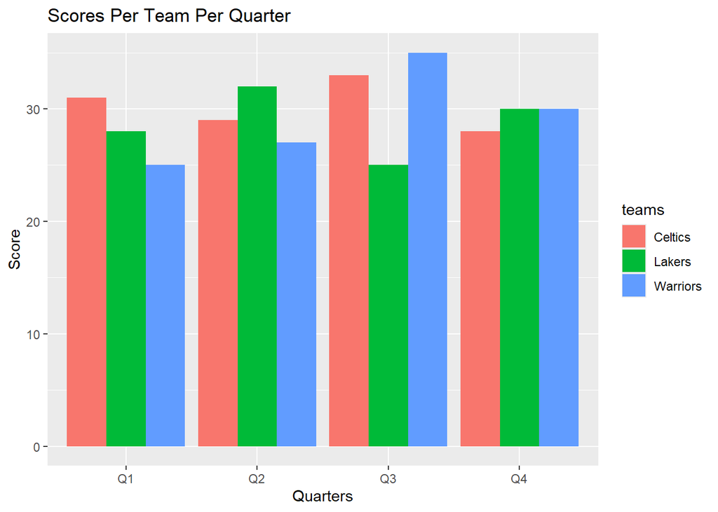

```r
basketball_df |>
  ggplot(aes(quarter, scores, fill = teams)) +
  geom_col(position = "dodge") +
  labs(title = "Scores Per Team Per Quarter",
       x = "Quarters",
       y = "Score")
```

```r
basketball_df |>
  group_by(teams) |>
  slice_max(scores, n = 1, with_ties = FALSE) |>
  select(teams, quarter, scores)
```

```
# A tibble: 3 × 3
# Groups:   teams [3]
  teams    quarter scores
  <chr>    <fct>    <dbl>
1 Celtics  Q3          33
2 Lakers   Q2          32
3 Warriors Q3          35
```

From the ggplot we can see that the data is pretty average, where all four quarters had somewhat equal scoring. When we look at the summarization table, we can see that the Celtics highest scoring quarter was Q3, Warriors was Q3, and Lakers was Q2.